# Session 4 — Excess Zeros and Model Checking

Expected zeros · structural zeros · zero-inflated and hurdle models · checking fit · autocorrelation · Lab 4

Community Medicine Workshop

## Where we are

- Session 3: overdispersion and the negative binomial
- Today: **too many zeros**, and **does the model fit?**
- By the end you can:
  - compare **observed and expected zeros**
  - tell **structural** from **sampling** zeros
  - fit and judge a **zero-inflated** model
  - check the fit **over time** and for **leftover correlation**

# Topic 1 — Zeros

## Are there too many?

```r
m_nb <- MASS::glm.nb(cases ~ fogging + slum + rain_lag1 + month_index + sin(2 * pi * month / 12) + cos(2 * pi * month / 12) + offset(log(population)), data = dg)
c(observed = round(mean(dg$cases == 0), 3), nb_expected = round(mean(dnbinom(0, mu = fitted(m_nb), size = m_nb$theta)), 3))
```

```
   observed nb_expected
      0.202       0.186
```

- A good negative binomial **already allows many zeros**: here it expects about **19%** and **20%** are observed, a **small excess**
- **More zeros than a count model expects** needs an explanation, not automatically a new model

## Where do the zeros come from?

```r
dg |> group_by(ward) |> summarise(zero_months = sum(cases == 0), mean_cases = round(mean(cases), 1)) |> arrange(desc(zero_months)) |> head(6)
```

```
# A tibble: 6 × 3
  ward  zero_months mean_cases
  <fct>       <int>      <dbl>
1 W14            24        0.9
2 W02            21        2.9
3 W04            18        4.1
4 W23            18       11.6
5 W12            16        3.9
6 W20            13        2.8
```

A few wards report **zero for half of the months**. That is not “no dengue”: it is **weak surveillance**. These are **structural zeros** (the count process is switched off), as opposed to **sampling zeros** (low mean, no case by chance).

# Topic 2 — Zero-inflated models

## Two processes

P(Y = 0) = pi + (1 - pi) x P<sub>count</sub>(0) P(Y = k) = (1 - pi) x P<sub>count</sub>(k)

- **Zero-inflated:** with probability **pi** the ward-month is a structural zero; otherwise counts follow Poisson or NB
- **Hurdle:** a binary part (any case?) and a **zero-truncated** count part
- Fit with `pscl::zeroinfl(y ~ x | z, dist = "negbin")`: the part after `|` models **pi**

## Fitting it

```r
m_zinb <- zeroinfl(cases ~ fogging + slum + rain_lag1 + month_index + sin(2 * pi * month / 12) + cos(2 * pi * month / 12) + offset(log(population)) | 1, data = dg, dist = "negbin")
c(structural_zero_probability = round(plogis(coef(m_zinb, "zero")), 3)); AIC(m_nb, m_zinb)
```

```
structural_zero_probability.(Intercept)
                                   0.06
```

```
       df      AIC
m_nb    8 5898.446
m_zinb  9 5871.452
```

## Be cautious

- AIC improves, but only modestly here (about 27 points)
- **First look for a covariate** that explains the zeros (a reporting-quality indicator): the zero part can then use it (`| reporting`)
- Do not add a mixture just because there are zeros: ask **why**
- Interpretation: the **count part** gives rate ratios **among at-risk ward-months**

# Topic 3 — Checking the fit

## Observed against fitted, over time

```r
dg |> mutate(pred = fitted(m_nb)) |> group_by(date) |> summarise(observed = sum(cases), predicted = sum(pred)) |>
  pivot_longer(c(observed, predicted)) |> ggplot(aes(date, value, colour = name)) + geom_line(linewidth = 1) + labs(x = NULL, y = "Cases", colour = NULL)
```

## Observed against fitted, over time

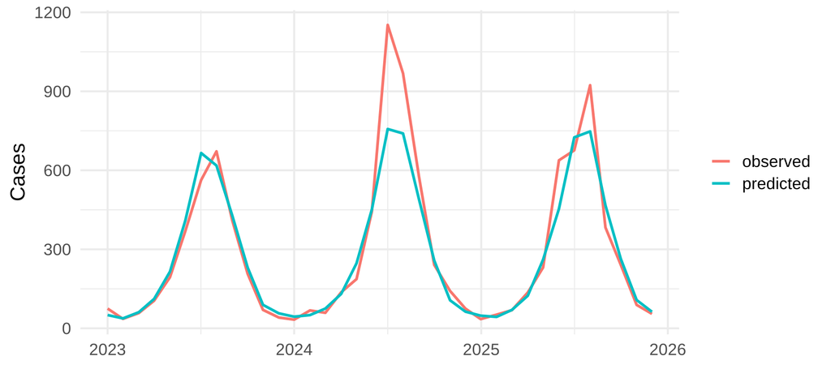

## Leftover correlation

```r
w1 <- dg$ward == levels(dg$ward)[1]
round(acf(residuals(m_nb, type = "pearson")[w1], plot = FALSE)$acf[1:4], 2)
```

```
[1]  1.00  0.13  0.04 -0.06
```

- **Autocorrelation** of residuals within a ward: lag 1 is 0.13, so consecutive months are **somewhat dependent**
- Consequence: standard errors **slightly optimistic**; fix with **clustered robust SEs**, random effects, or time-series terms (lagged cases)
- Also check **residuals by predictor** and **by ward**

## Model-checking checklist

1. **Dispersion** and **zeros**: observed vs expected
2. **Observed vs predicted** over time
3. **Autocorrelation** of residuals
4. **Influential** wards: refit leaving one ward out
5. **Sensitivity**: Poisson, NB, zero-inflated: do the **rate ratios** agree?

## 🔧 Switch to R — Lab 4

**File:** `counts-workshop/labs/lab4_zeros.R`

- expected zeros from the NB model; zero months by ward
- `pscl::zeroinfl()` and AIC
- observed vs predicted over time; `acf()` of residuals

**Time:** 35 minutes · answer the Q questions in the comments

## Self-check quiz (1/5)

A negative binomial model expects 19% zeros and 20% are observed. What should you conclude?

- The model has failed completely and its output is of no use at all
- The data cannot be analysed with a count model of any type here
- Only a small excess, so zero-inflation is not clearly needed
- Every ward has the same chance of recording a zero in a month

## Self-check quiz (2/5)

What is a structural zero?

- A zero that arises by chance because the mean count is small here
- A zero from a process that gives no counts, such as non-reporting
- A zero caused by a coding error in the file that should be fixed first
- Any month of the series with fewer than five cases in the ward

## Self-check quiz (3/5)

In a zero-inflated model, the part after the vertical bar models what?

- The mean of the count process for the ward-months that are at risk
- The offset, which is the log of the population of the ward
- The probability of a structural zero (the zero-inflation part)
- The dispersion parameter theta of the negative binomial count part

## Self-check quiz (4/5)

What is the best first step when a model shows more zeros than expected?

- Add a zero-inflation term straight away without more thought
- Delete every row that contains a zero count from the data
- Switch to linear regression on the log of the monthly counts
- Find out why, and look for a covariate that explains them

## Self-check quiz (5/5)

Residuals of a ward over successive months have lag-1 autocorrelation 0.13. What does that imply?

- Months are dependent; standard errors are optimistic
- The model is perfect and no further checks are needed at all
- The ward must be removed from the data before the next fit
- The offset has the wrong sign in the model that was fitted

## Score and take-home

**Your score:**

- Compare **observed and expected zeros** from the fitted model
- **Structural** zeros need a reason (reporting); not every excess needs a mixture
- `zeroinfl(y ~ x | z, dist = negbin)`; compare **AIC** and **rate ratios**
- Check fit **over time**, **autocorrelation** and **influential wards**

**Next:** Session 5: reporting and extensions